# HW Template

2023-11-05

## Preliminaries

Put all `library()` calls here. Also load **ALL** data objects necessary for the home work assingment here.

For example, the code below loads the `tidyverse` and the `lterdatasampler` packages. It also reads in the `galapagos-finches.csv` data file (make sure it is downloaded *and* in your `data/` folder). It also loads the `and_vertebrates` data which comes in the `lterdatasampler` package.

```r
library(tidyverse)
library(lterdatasampler)
finch <- read_csv("data/galapago-finches.csv")
data(and_vertebrates)
```

## Problem 1

All problems need a level 2 heading (i.e., two ## ).

All sub-problems need a level 3 heading (i.e., ###) as well as the number of the problem and sub-problem.

For example:

### Problem 1.1

Below the level 3 heading, you can type plain text if needed to answer the question. If you need to run calculations in R, you will need to insert a new code chunk (mac: Cmd + Option + I, Windows Ctrl + Alt + I).

```r
head(finch)
```

```
## # A tibble: 6 × 5
##    year  band species blength bdepth
##   <dbl> <dbl> <chr>     <dbl>  <dbl>
## 1  2012 19022 fortis     10      8.5
## 2  2012 19028 fortis     12.5    8.9
## 3  2012 19032 fortis      9.3    7.5
## 4  2012 19041 fortis     10.3    9.6
## 5  2012 19044 fortis     11      9.2
## 6  2012 19048 fortis     10.1    8.2
```

**Example answer for 1.1:** The first few rows of `finches` are shown. All variables are class double, except for `species` which is a character vector.

### Problem 1.2

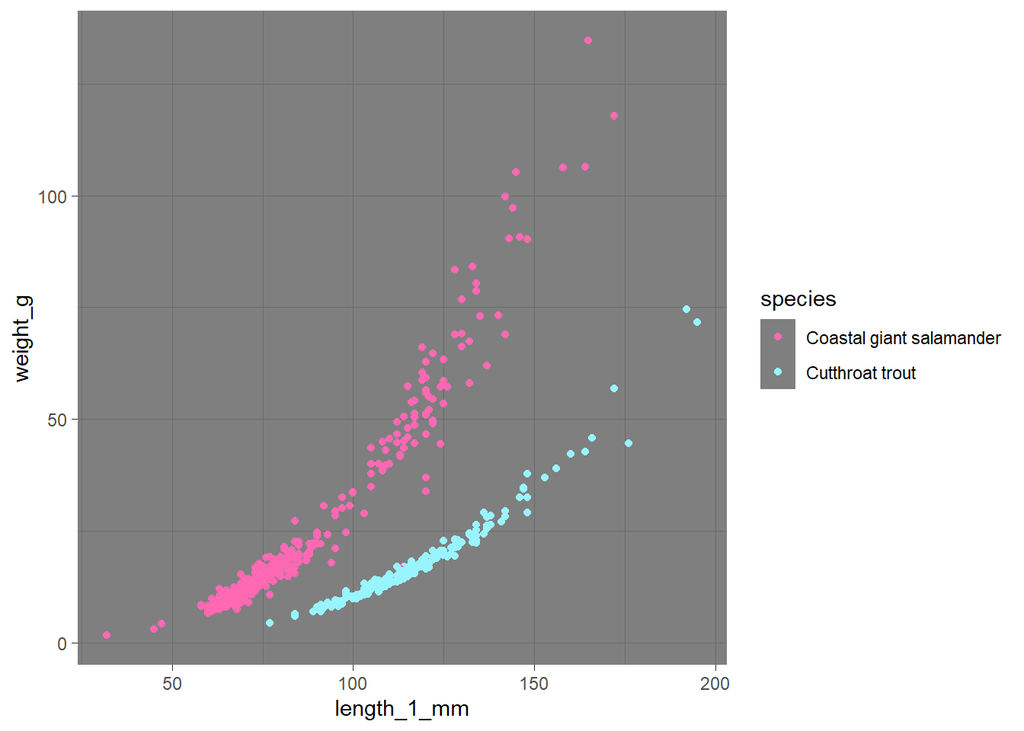

```r
and_vertebrates %>%
  na.omit() %>%
  ggplot(aes(x = length_1_mm,
             y = weight_g,
             color = species)) +
  geom_point() +
  theme_dark() +
  scale_color_manual(values = c("hotpink", "cadetblue1"))
```

**Example answer for 1.2:** The slope for coastal giant salamander (pink) is steeper than cutthroat trout (blue).

## Problem 2

### 2.1

## Problem 3